*-----ANÁLISE DE DADOS DO COVID-19-----*

```python
import numpy as np
import pandas as pd
import matplotlib.pyplot as plt
import seaborn as sns
```

*-----IMPORTANDO O ARQUIVO CSV-----*

```python
df = pd.read_csv('/home/lucas/Downloads/HIST_PAINEL_COVIDBR_2020_Parte1_25nov2021.csv', sep=';')
df
```

|  | regiao | estado | municipio | coduf | codmun | codRegiaoSaude | nomeRegiaoSaude | data | semanaEpi | populacaoTCU2019 | casosAcumulado | casosNovos | obitosAcumulado | obitosNovos | Recuperadosnovos | emAcompanhamentoNovos | interior/metropolitana |
| --- | --- | --- | --- | --- | --- | --- | --- | --- | --- | --- | --- | --- | --- | --- | --- | --- | --- |
| 0 | Brasil | NaN | NaN | 76 | NaN | NaN | NaN | 2020-02-25 | 9 | 210147125.0 | 0 | 0 | 0 | 0 | NaN | NaN | NaN |
| 1 | Brasil | NaN | NaN | 76 | NaN | NaN | NaN | 2020-02-26 | 9 | 210147125.0 | 1 | 1 | 0 | 0 | NaN | NaN | NaN |
| 2 | Brasil | NaN | NaN | 76 | NaN | NaN | NaN | 2020-02-27 | 9 | 210147125.0 | 1 | 0 | 0 | 0 | NaN | NaN | NaN |
| 3 | Brasil | NaN | NaN | 76 | NaN | NaN | NaN | 2020-02-28 | 9 | 210147125.0 | 1 | 0 | 0 | 0 | NaN | NaN | NaN |
| 4 | Brasil | NaN | NaN | 76 | NaN | NaN | NaN | 2020-02-29 | 9 | 210147125.0 | 2 | 1 | 0 | 0 | NaN | NaN | NaN |
| ... | ... | ... | ... | ... | ... | ... | ... | ... | ... | ... | ... | ... | ... | ... | ... | ... | ... |
| 714476 | Centro-Oeste | DF | Brasília | 53 | 530010.0 | 53001.0 | DISTRITO FEDERAL | 2020-07-27 | 31 | 3015268.0 | 98480 | 2148 | 1339 | 31 | NaN | NaN | 1.0 |
| 714477 | Centro-Oeste | DF | Brasília | 53 | 530010.0 | 53001.0 | DISTRITO FEDERAL | 2020-07-28 | 31 | 3015268.0 | 100726 | 2246 | 1391 | 52 | NaN | NaN | 1.0 |
| 714478 | Centro-Oeste | DF | Brasília | 53 | 530010.0 | 53001.0 | DISTRITO FEDERAL | 2020-07-29 | 31 | 3015268.0 | 102342 | 1616 | 1419 | 28 | NaN | NaN | 1.0 |
| 714479 | Centro-Oeste | DF | Brasília | 53 | 530010.0 | 53001.0 | DISTRITO FEDERAL | 2020-07-30 | 31 | 3015268.0 | 104442 | 2100 | 1444 | 25 | NaN | NaN | 1.0 |
| 714480 | Centro-Oeste | DF | Brasília | 53 | 530010.0 | 53001.0 | DISTRITO FEDERAL | 2020-07-31 | 31 | 3015268.0 | 106292 | 1850 | 1469 | 25 | NaN | NaN | 1.0 |

714481 rows × 17 columns

-----DADOS DO 30º DIA

```python
df[df.index == 30]
```

|  | regiao | estado | municipio | coduf | codmun | codRegiaoSaude | nomeRegiaoSaude | data | semanaEpi | populacaoTCU2019 | casosAcumulado | casosNovos | obitosAcumulado | obitosNovos | Recuperadosnovos | emAcompanhamentoNovos | interior/metropolitana |
| --- | --- | --- | --- | --- | --- | --- | --- | --- | --- | --- | --- | --- | --- | --- | --- | --- | --- |
| 30 | Brasil | NaN | NaN | 76 | NaN | NaN | NaN | 2020-03-26 | 13 | 210147125.0 | 2915 | 482 | 77 | 20 | NaN | NaN | NaN |

```python
df[df.estado == "CE"].casosNovos.value_counts().head(6)
```

```
0    12030
1     2692
2     1344
3      866
4      686
5      522
Name: casosNovos, dtype: int64
```

*-----DIAS NO CEARÁ COM ÓBITOS ACIMA DE 100 PESSOAS-----*

```python
df[df.estado == "CE"][df.obitosNovos > 100]
```

|  | regiao | estado | municipio | coduf | codmun | codRegiaoSaude | nomeRegiaoSaude | data | semanaEpi | populacaoTCU2019 | casosAcumulado | casosNovos | obitosAcumulado | obitosNovos | Recuperadosnovos | emAcompanhamentoNovos | interior/metropolitana |
| --- | --- | --- | --- | --- | --- | --- | --- | --- | --- | --- | --- | --- | --- | --- | --- | --- | --- |
| 1647 | Nordeste | CE | NaN | 23 | NaN | NaN | NaN | 2020-05-02 | 18 | 9132078.0 | 8231 | 352 | 614 | 109 | NaN | NaN | NaN |
| 1658 | Nordeste | CE | NaN | 23 | NaN | NaN | NaN | 2020-05-13 | 20 | 9132078.0 | 19156 | 744 | 1389 | 109 | NaN | NaN | NaN |
| 1661 | Nordeste | CE | NaN | 23 | NaN | NaN | NaN | 2020-05-16 | 20 | 9132078.0 | 23795 | 1305 | 1614 | 138 | NaN | NaN | NaN |
| 1663 | Nordeste | CE | NaN | 23 | NaN | NaN | NaN | 2020-05-18 | 21 | 9132078.0 | 26363 | 2108 | 1748 | 107 | NaN | NaN | NaN |
| 1664 | Nordeste | CE | NaN | 23 | NaN | NaN | NaN | 2020-05-19 | 21 | 9132078.0 | 28112 | 1749 | 1856 | 108 | NaN | NaN | NaN |
| 1666 | Nordeste | CE | NaN | 23 | NaN | NaN | NaN | 2020-05-21 | 21 | 9132078.0 | 31413 | 853 | 2161 | 261 | NaN | NaN | NaN |
| 1670 | Nordeste | CE | NaN | 23 | NaN | NaN | NaN | 2020-05-25 | 22 | 9132078.0 | 36185 | 590 | 2493 | 169 | NaN | NaN | NaN |
| 1671 | Nordeste | CE | NaN | 23 | NaN | NaN | NaN | 2020-05-26 | 22 | 9132078.0 | 37021 | 836 | 2603 | 110 | NaN | NaN | NaN |
| 1674 | Nordeste | CE | NaN | 23 | NaN | NaN | NaN | 2020-05-29 | 22 | 9132078.0 | 38395 | 574 | 2859 | 126 | NaN | NaN | NaN |
| 1677 | Nordeste | CE | NaN | 23 | NaN | NaN | NaN | 2020-06-01 | 23 | 9132078.0 | 50504 | 2015 | 3188 | 178 | NaN | NaN | NaN |
| 1678 | Nordeste | CE | NaN | 23 | NaN | NaN | NaN | 2020-06-02 | 23 | 9132078.0 | 53073 | 2569 | 3421 | 233 | NaN | NaN | NaN |
| 1679 | Nordeste | CE | NaN | 23 | NaN | NaN | NaN | 2020-06-03 | 23 | 9132078.0 | 56056 | 2983 | 3605 | 184 | NaN | NaN | NaN |
| 1680 | Nordeste | CE | NaN | 23 | NaN | NaN | NaN | 2020-06-04 | 23 | 9132078.0 | 59795 | 3739 | 3813 | 208 | NaN | NaN | NaN |
| 1684 | Nordeste | CE | NaN | 23 | NaN | NaN | NaN | 2020-06-08 | 24 | 9132078.0 | 65605 | 1334 | 4120 | 138 | NaN | NaN | NaN |
| 1685 | Nordeste | CE | NaN | 23 | NaN | NaN | NaN | 2020-06-09 | 24 | 9132078.0 | 68384 | 2779 | 4309 | 189 | NaN | NaN | NaN |
| 1686 | Nordeste | CE | NaN | 23 | NaN | NaN | NaN | 2020-06-10 | 24 | 9132078.0 | 71402 | 3018 | 4480 | 171 | NaN | NaN | NaN |
| 1687 | Nordeste | CE | NaN | 23 | NaN | NaN | NaN | 2020-06-11 | 24 | 9132078.0 | 73879 | 2477 | 4663 | 183 | NaN | NaN | NaN |
| 1688 | Nordeste | CE | NaN | 23 | NaN | NaN | NaN | 2020-06-12 | 24 | 9132078.0 | 75705 | 1826 | 4788 | 125 | NaN | NaN | NaN |
| 1691 | Nordeste | CE | NaN | 23 | NaN | NaN | NaN | 2020-06-15 | 25 | 9132078.0 | 79462 | 2714 | 4999 | 138 | NaN | NaN | NaN |
| 1693 | Nordeste | CE | NaN | 23 | NaN | NaN | NaN | 2020-06-17 | 25 | 9132078.0 | 84967 | 3678 | 5282 | 212 | NaN | NaN | NaN |
| 1699 | Nordeste | CE | NaN | 23 | NaN | NaN | NaN | 2020-06-23 | 26 | 9132078.0 | 97528 | 3370 | 5717 | 113 | NaN | NaN | NaN |
| 1708 | Nordeste | CE | NaN | 23 | NaN | NaN | NaN | 2020-07-02 | 27 | 9132078.0 | 115524 | 2507 | 6284 | 104 | NaN | NaN | NaN |
| 1714 | Nordeste | CE | NaN | 23 | NaN | NaN | NaN | 2020-07-08 | 28 | 9132078.0 | 128471 | 3519 | 6665 | 109 | NaN | NaN | NaN |
| 1734 | Nordeste | CE | NaN | 23 | NaN | NaN | NaN | 2020-07-28 | 31 | 9132078.0 | 165550 | 3121 | 7613 | 104 | NaN | NaN | NaN |
| 125764 | Nordeste | CE | Fortaleza | 23 | 230440.0 | 23001.0 | 1ª REGIAO FORTALEZA | 2020-05-21 | 21 | 2669342.0 | 18644 | 634 | 1503 | 170 | NaN | NaN | 1.0 |
| 125768 | Nordeste | CE | Fortaleza | 23 | 230440.0 | 23001.0 | 1ª REGIAO FORTALEZA | 2020-05-25 | 22 | 2669342.0 | 20146 | 351 | 1687 | 108 | NaN | NaN | 1.0 |
| 125775 | Nordeste | CE | Fortaleza | 23 | 230440.0 | 23001.0 | 1ª REGIAO FORTALEZA | 2020-06-01 | 23 | 2669342.0 | 24104 | 491 | 2084 | 117 | NaN | NaN | 1.0 |
| 125776 | Nordeste | CE | Fortaleza | 23 | 230440.0 | 23001.0 | 1ª REGIAO FORTALEZA | 2020-06-02 | 23 | 2669342.0 | 24897 | 793 | 2231 | 147 | NaN | NaN | 1.0 |
| 125777 | Nordeste | CE | Fortaleza | 23 | 230440.0 | 23001.0 | 1ª REGIAO FORTALEZA | 2020-06-03 | 23 | 2669342.0 | 25726 | 829 | 2334 | 103 | NaN | NaN | 1.0 |
| 125791 | Nordeste | CE | Fortaleza | 23 | 230440.0 | 23001.0 | 1ª REGIAO FORTALEZA | 2020-06-17 | 25 | 2669342.0 | 31779 | 630 | 3053 | 110 | NaN | NaN | 1.0 |

*-----FILTRAR APENAS POR DADOS GERAIS DO PAÍS-----*

```python
df[df.estado.isna()]
```

|  | regiao | estado | municipio | coduf | codmun | codRegiaoSaude | nomeRegiaoSaude | data | semanaEpi | populacaoTCU2019 | casosAcumulado | casosNovos | obitosAcumulado | obitosNovos | Recuperadosnovos | emAcompanhamentoNovos | interior/metropolitana |
| --- | --- | --- | --- | --- | --- | --- | --- | --- | --- | --- | --- | --- | --- | --- | --- | --- | --- |
| 0 | Brasil | NaN | NaN | 76 | NaN | NaN | NaN | 2020-02-25 | 9 | 210147125.0 | 0 | 0 | 0 | 0 | NaN | NaN | NaN |
| 1 | Brasil | NaN | NaN | 76 | NaN | NaN | NaN | 2020-02-26 | 9 | 210147125.0 | 1 | 1 | 0 | 0 | NaN | NaN | NaN |
| 2 | Brasil | NaN | NaN | 76 | NaN | NaN | NaN | 2020-02-27 | 9 | 210147125.0 | 1 | 0 | 0 | 0 | NaN | NaN | NaN |
| 3 | Brasil | NaN | NaN | 76 | NaN | NaN | NaN | 2020-02-28 | 9 | 210147125.0 | 1 | 0 | 0 | 0 | NaN | NaN | NaN |
| 4 | Brasil | NaN | NaN | 76 | NaN | NaN | NaN | 2020-02-29 | 9 | 210147125.0 | 2 | 1 | 0 | 0 | NaN | NaN | NaN |
| ... | ... | ... | ... | ... | ... | ... | ... | ... | ... | ... | ... | ... | ... | ... | ... | ... | ... |
| 153 | Brasil | NaN | NaN | 76 | NaN | NaN | NaN | 2020-07-27 | 31 | 210147125.0 | 2442375 | 23284 | 87618 | 614 | 1667667.0 | 687090.0 | NaN |
| 154 | Brasil | NaN | NaN | 76 | NaN | NaN | NaN | 2020-07-28 | 31 | 210147125.0 | 2483191 | 40816 | 88539 | 921 | 1721560.0 | 673092.0 | NaN |
| 155 | Brasil | NaN | NaN | 76 | NaN | NaN | NaN | 2020-07-29 | 31 | 210147125.0 | 2552265 | 69074 | 90134 | 1595 | 1786753.0 | 675378.0 | NaN |
| 156 | Brasil | NaN | NaN | 76 | NaN | NaN | NaN | 2020-07-30 | 31 | 210147125.0 | 2610102 | 57837 | 91263 | 1129 | 1824095.0 | 694744.0 | NaN |
| 157 | Brasil | NaN | NaN | 76 | NaN | NaN | NaN | 2020-07-31 | 31 | 210147125.0 | 2662485 | 52383 | 92475 | 1212 | 1844051.0 | 725959.0 | NaN |

158 rows × 17 columns

*-----CRIAÇÃO DA TABELA DE ÓBITOS TOTAIS-----*

```python
df['obitosTotais'] = df['obitosAcumulado'] + df['obitosNovos']
df.tail()
```

|  | regiao | estado | municipio | coduf | codmun | codRegiaoSaude | nomeRegiaoSaude | data | semanaEpi | populacaoTCU2019 | casosAcumulado | casosNovos | obitosAcumulado | obitosNovos | Recuperadosnovos | emAcompanhamentoNovos | interior/metropolitana | obitosTotais |
| --- | --- | --- | --- | --- | --- | --- | --- | --- | --- | --- | --- | --- | --- | --- | --- | --- | --- | --- |
| 714476 | Centro-Oeste | DF | Brasília | 53 | 530010.0 | 53001.0 | DISTRITO FEDERAL | 2020-07-27 | 31 | 3015268.0 | 98480 | 2148 | 1339 | 31 | NaN | NaN | 1.0 | 1370 |
| 714477 | Centro-Oeste | DF | Brasília | 53 | 530010.0 | 53001.0 | DISTRITO FEDERAL | 2020-07-28 | 31 | 3015268.0 | 100726 | 2246 | 1391 | 52 | NaN | NaN | 1.0 | 1443 |
| 714478 | Centro-Oeste | DF | Brasília | 53 | 530010.0 | 53001.0 | DISTRITO FEDERAL | 2020-07-29 | 31 | 3015268.0 | 102342 | 1616 | 1419 | 28 | NaN | NaN | 1.0 | 1447 |
| 714479 | Centro-Oeste | DF | Brasília | 53 | 530010.0 | 53001.0 | DISTRITO FEDERAL | 2020-07-30 | 31 | 3015268.0 | 104442 | 2100 | 1444 | 25 | NaN | NaN | 1.0 | 1469 |
| 714480 | Centro-Oeste | DF | Brasília | 53 | 530010.0 | 53001.0 | DISTRITO FEDERAL | 2020-07-31 | 31 | 3015268.0 | 106292 | 1850 | 1469 | 25 | NaN | NaN | 1.0 | 1494 |

*-----MÁXIMO DE ÓBITOS REGISTRADOS NOS ESTADOS-----*

```python
agrupa_estado = df.groupby('estado')
a = agrupa_estado.obitosNovos.max().sort_values()
a
```

```
estado
TO     15
AC     16
AP     18
MS     20
RO     31
PI     36
SE     39
AL     39
RR     40
PB     46
DF     52
SC     59
ES     63
RN     70
PR     71
BA     72
RS     75
MA     77
GO     92
MG     95
AM    102
PE    140
PA    224
MT    245
CE    261
RJ    324
SP    713
Name: obitosNovos, dtype: int64
```

*-----MÁXIMO DE CASOS NOVOS REGISTRADOS EM APENAS UM DIA-----*

```python
df.casosNovos.max()            #Vai retornar 69074
df[df.casosNovos == 69074]
```

|  | regiao | estado | municipio | coduf | codmun | codRegiaoSaude | nomeRegiaoSaude | data | semanaEpi | populacaoTCU2019 | casosAcumulado | casosNovos | obitosAcumulado | obitosNovos | Recuperadosnovos | emAcompanhamentoNovos | interior/metropolitana | obitosTotais |
| --- | --- | --- | --- | --- | --- | --- | --- | --- | --- | --- | --- | --- | --- | --- | --- | --- | --- | --- |
| 155 | Brasil | NaN | NaN | 76 | NaN | NaN | NaN | 2020-07-29 | 31 | 210147125.0 | 2552265 | 69074 | 90134 | 1595 | 1786753.0 | 675378.0 | NaN | 91729 |

*-----MÉDIA DE CASOS NOVOS NOS ÚLTIMOS 100 DIAS-----*

```python
ultimos_50_dias = df.tail(100)
ultimos_50_dias.casosNovos.mean()
```

```
1053.46
```

*----- VARIAÇÃO DE CASOS NOVOS NO BRASIL -----*

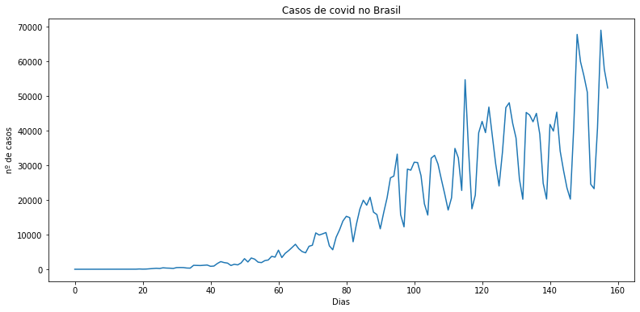

```python
ax = casos_novos_BR = df[df.estado.isna()].casosNovos.plot(
figsize=(13,6),xlabel="Dias",ylabel="nº de casos",title="Casos de covid no Brasil")
casos_novos_BR
```

*-----VARIAÇÃO DE CASOS ACUMULADOS NO BRASIL-----*

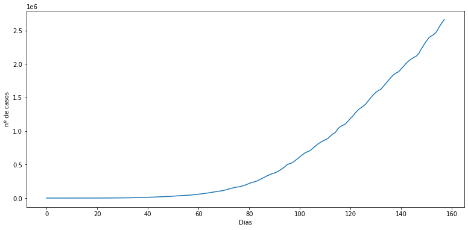

```python
casos_acumulados_BR = df[df.estado.isna()].casosAcumulado.plot(xlabel="Dias",ylabel="nº de casos",figsize=(13,6))
casos_acumulados_BR
```

*-----ÓBITOS NOVOS NO BRASIL-----*

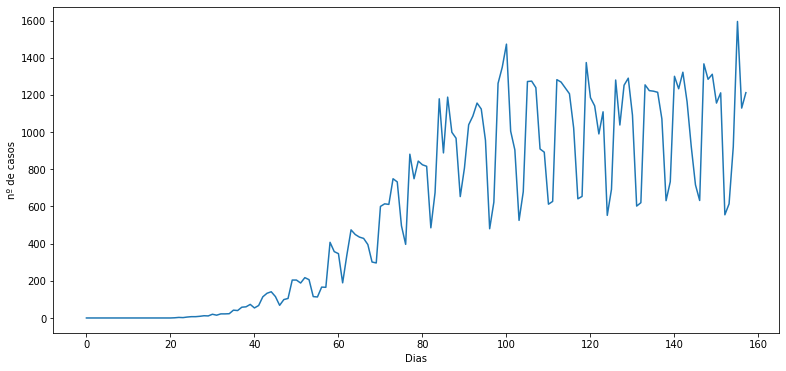

```python
casos_acumulados_BR = df[df.estado.isna()].obitosNovos.plot(xlabel="Dias",ylabel="nº de casos",figsize=(13,6))
casos_acumulados_BR
```

*-----ÓBITOS ACUMULADOS NO BRASIL-----*

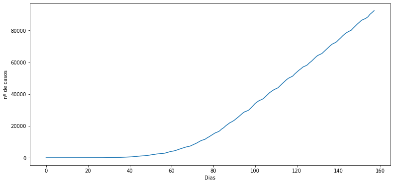

```python
casos_acumulados_BR = df[df.estado.isna()].obitosAcumulado.plot(xlabel="Dias",ylabel="nº de casos")
casos_acumulados_BR
```

*-----COMPARAÇÃO ENTRE CASOS E OBITOS-----*

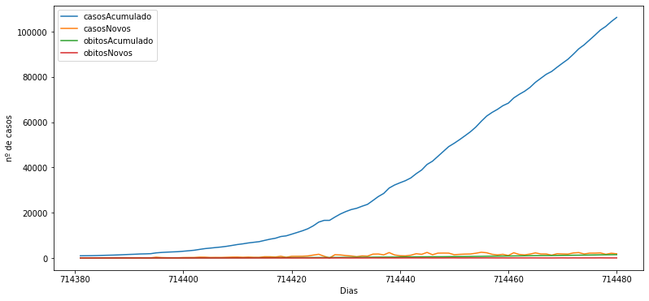

```python
df = pd.concat([df.casosAcumulado.tail(100),df.casosNovos.tail(100),df.obitosAcumulado.tail(100),df.obitosNovos.tail(100)],axis =1)
df.plot(figsize=(13,6),title=(""),ylabel="nº de casos")
```

*-----COMPARAÇÃO ENTRE NOVOS CASOS E ÓBITOS (SEM OS CASOS ACUMULADOS)-----*

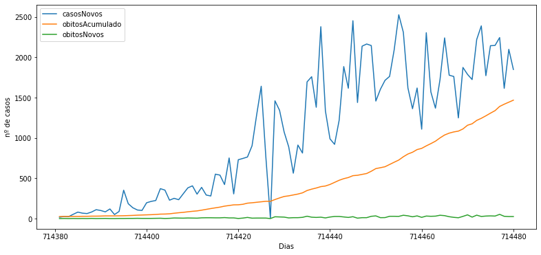

```python
df = pd.concat([df.casosNovos.tail(100),df.obitosAcumulado.tail(100),df.obitosNovos.tail(100)],axis =1)
df.plot(figsize=(13,6),title=(""),xlabel="Dias",ylabel="nº de casos")
```

*-----VARIAÇÃO DE CASOS NOVOS NO CEARÁ-----*

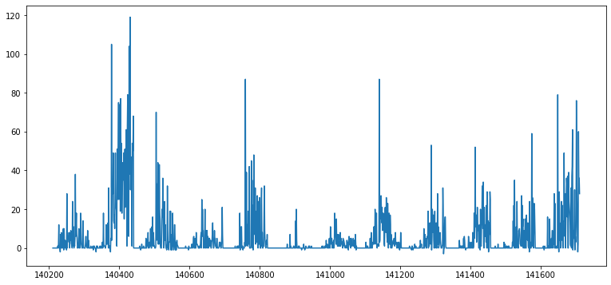

```python
df[df.estado == "CE"].tail(1500).casosNovos.plot(figsize=(13,6))
```

*-----SOMA TOTAL DE ÓBITOS NO CEARÁ-----*

```python
df[df.estado == "CE"].obitosNovos.sum()
```

```
15336
```

*-----VARIAÇÃO DE CASOS NOVOS EM FORTALEZA------*

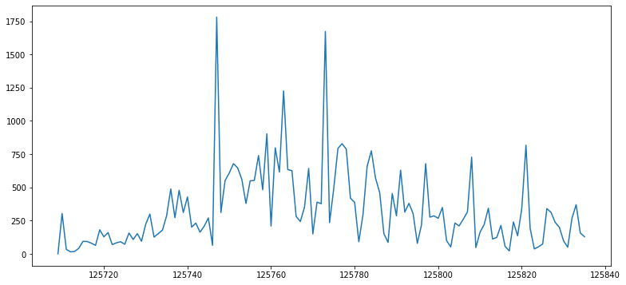

```python
casos_em_fortaleza = df[df.municipio == "Fortaleza"].casosNovos.plot(figsize=(13,6))
```

*-----VARIAÇÃO DE CASOS NOVOS EM SALVADOR-----*

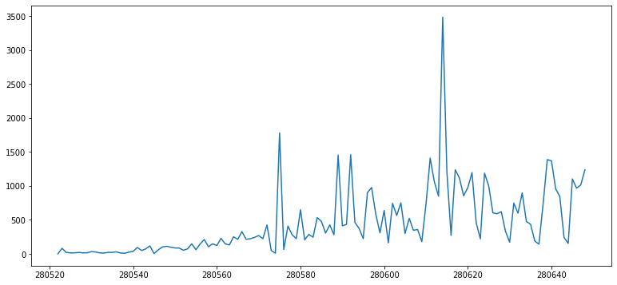

```python
casos_em_salv = df[df.municipio == "Salvador"].casosNovos.plot(figsize=(13,6))
```

*-----VARIAÇÃO DE CASOS NOVOS EM TERESINA-----*

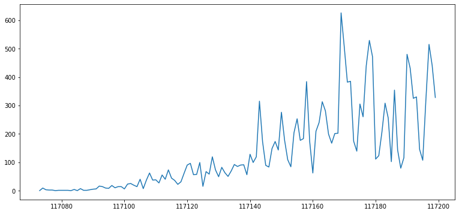

```python
casos_em_nat = df[df.municipio == "Teresina"].casosNovos.plot(figsize=(13,6))
```

*-----VARIAÇÃO DE CASOS EM FORTALEZA-----*

```
<BarContainer object of 127 artists>
```

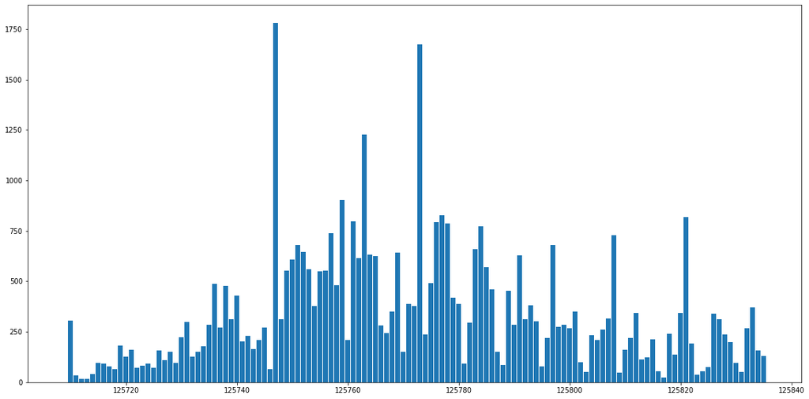

```python
import matplotlib.pyplot as plt

y = df[df.municipio == "Fortaleza"].casosNovos
x = df[df.municipio == "Fortaleza"].index


plt.figure(figsize=(20,10))

plt.bar(x,y)
```

*-----COMPRAÇÃO ÓBITOS X CASOS NOVOS-----*

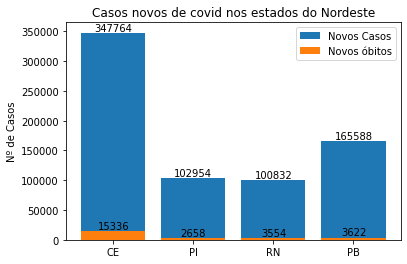

```python
estados = ['CE','PI','RN','PB']
casos_novos = [df[df.estado == "CE"].casosNovos.sum(),df[df.estado == "PI"].casosNovos.sum(),df[df.estado == "RN"].casosNovos.sum(),df[df.estado == "PB"].casosNovos.sum()]
obitos_novos = [df[df.estado == "CE"].obitosNovos.sum(),df[df.estado == "PI"].obitosNovos.sum(),df[df.estado == "RN"].obitosNovos.sum(),df[df.estado == "PB"].obitosNovos.sum()]

ypos = np.arange(len(estados))

for i in range(len(estados)):
  plt.text(i,casos_novos[i],casos_novos[i],ha="center",va="bottom")
  plt.text(i,obitos_novos[i],obitos_novos[i],ha="center",va="bottom")


plt.title("Casos novos de covid nos estados do Nordeste")
plt.ylabel("Nº de Casos")
plt.xticks(ypos,estados)
plt.bar(ypos,casos_novos, label="Novos Casos")
plt.bar(ypos,obitos_novos, label="Novos óbitos")
plt.legend()
```

*-----SOMATÓRIO TOTAL DE CASOS NOS ESTADOS DO NORDESTE-----*

```
No artists with labels found to put in legend.  Note that artists whose label start with an underscore are ignored when legend() is called with no argument.
```

```
<BarContainer object of 4 artists>
```

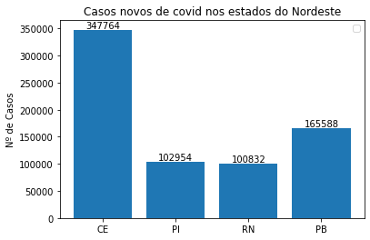

```python
estados = ['CE','PI','RN','PB']
casos_novos = [df[df.estado == "CE"].casosNovos.sum(),df[df.estado == "PI"].casosNovos.sum(),df[df.estado == "RN"].casosNovos.sum(),df[df.estado == "PB"].casosNovos.sum()]

ypos = np.arange(len(estados))

for i in range(len(estados)):
  plt.text(i,casos_novos[i],casos_novos[i],ha="center",va="bottom")



plt.legend()
plt.title("Casos novos de covid nos estados do Nordeste")
plt.ylabel("Nº de Casos")
plt.xticks(ypos,estados)
plt.bar(ypos,casos_novos)
```

*-----COMPARAÇÃO ENTRE NÚMERO DE ÓBITOS E NOVOS CASOS EM FORTALEZA-----*

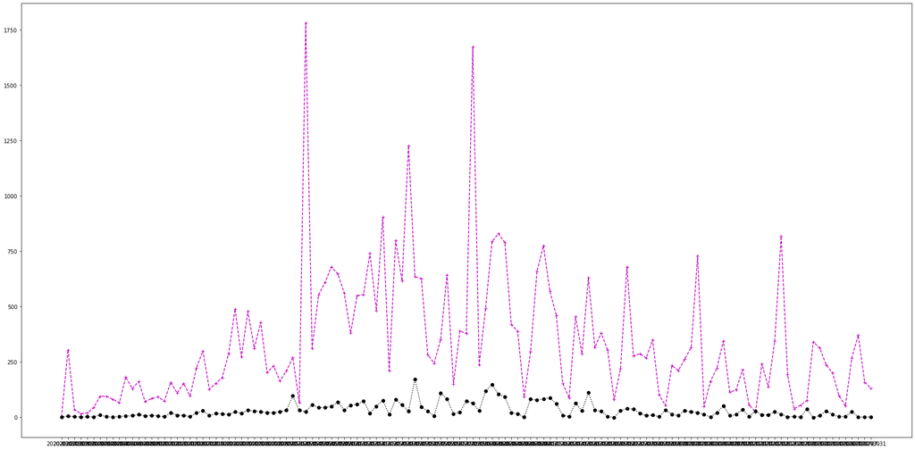

```python
y1 = df[df.municipio == "Fortaleza"].casosNovos
x1 = df[df.municipio == "Fortaleza"].data

y2 = df[df.municipio == "Fortaleza"].obitosNovos
x2 = df[df.municipio == "Fortaleza"].data

plt.figure(figsize=(30,15))
plt.xlabel="Dias"
plt.ylabel="nº de casos"
plt.plot (x1,y1, '+--m')
plt.plot (x2,y2 ,'o:k')
```

*-----COMPARAÇÃO ENTRE NÚMERO DE ÓBITOS E NOVOS CASOS EM FORTALEZA-----*

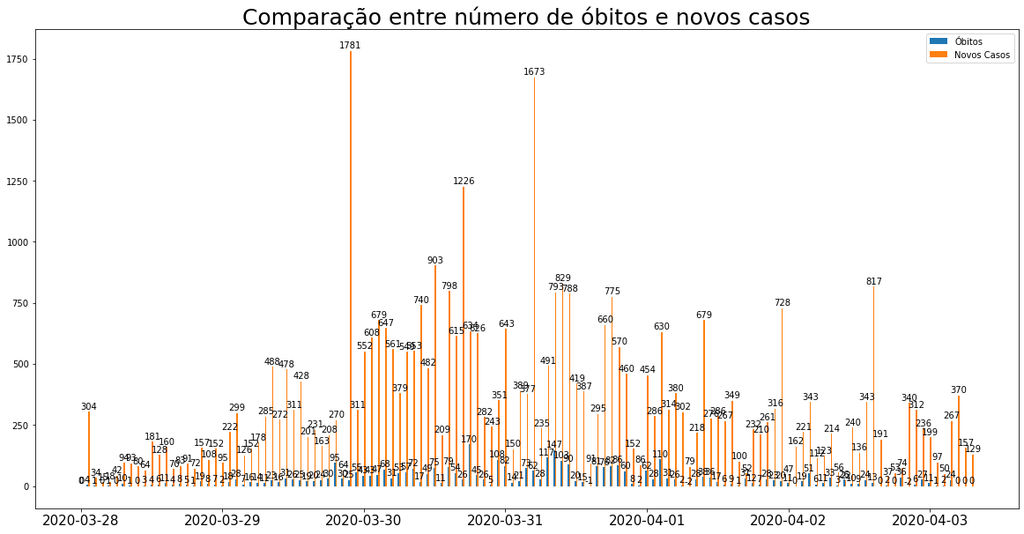

```python
def autolabel(grupos):
  for i in grupos:
    h = i.get_height()
    ax.annotate('{}'.format(h),
                xy = (i.get_x()+i.get_width() /2,h),
                xytext = (0,3),
                textcoords = 'offset points',
                ha = 'center')

data = df[df.municipio == "Fortaleza"].data

obitos = df[df.municipio == "Fortaleza"].obitosNovos
novos_casos = df[df.municipio == "Fortaleza"].casosNovos
x = np.arange(len(data))
largura = 0.20
fig,ax = plt.subplots(figsize = (20,10))
grupo1 = ax.bar(x -largura/2,obitos,largura,label = "Óbitos")
grupo2 = ax.bar(x +largura/2,novos_casos,largura,label = "Novos Casos")
ax.legend()
ax.set_title('Comparação entre número de óbitos e novos casos', fontsize = 25)
ax.set_xticklabels(data, fontsize = 15)

autolabel(grupo1)                                                                    #Define o número que aparece em cima da barra
autolabel(grupo2)                                                                    #Define o número que aparece em cima da barra

plt.show()
```

*-----PORCENTAGEM DE MORTOS EM RELAÇÃO À POPULAÇÃO-----*

```python
def porcentagem(a):
    print("A porcentagem de mortes em relação à população total do estado",a,
          "é: " "%",df[df.estado == a].obitosNovos.sum()/df[df.estado == a].populacaoTCU2019.max() * 100)
```

```python
porcentagem("CE")
porcentagem("BA")
porcentagem("RN")
porcentagem("PB")
porcentagem("PI")
porcentagem("AL")
porcentagem("MA")
porcentagem("SE")
```

```
A porcentagem de mortes em relação à população total do estado CE é: % 0.16793549069554597
A porcentagem de mortes em relação à população total do estado BA é: % 0.04656740534431909
A porcentagem de mortes em relação à população total do estado RN é: % 0.10134442475917868
A porcentagem de mortes em relação à população total do estado PB é: % 0.0901415012517026
A porcentagem de mortes em relação à população total do estado PI é: % 0.08120426722619604
A porcentagem de mortes em relação à população total do estado AL é: % 0.09390664528847228
A porcentagem de mortes em relação à população total do estado MA é: % 0.0851709659441928
A porcentagem de mortes em relação à população total do estado SE é: % 0.12476638929201599
```

- **-----Algumas perguntas que podem ser respondidas pós análise de dados-----** *

1.Qual estado do Nordeste obteve a maior média percentual de mortes por habitante?

R: O estado do Ceará apresentou a maior média percentual de mortes por habitante: %0.16 da população, equivalente a 15336 pessoas.

2.Qual estado do Nordeste obteve a menor média percentual de mortes por habitante?

R: O estado da Bahia apresentou a menor média percentual de mortes por habitante: %0.04 da população, equivalente a 6926 pessoas.

4.O que os gráficos de óbitos e casos novos no Brasil tem a nos dizer?

Dessa forma, é seguro afirmar que o pico da pandemia ainda não foi alcançado e que graças ao aumento de casos acumulados a expectativa é um aumento no número de mortes.

5.Qual a semelhança entre os gráficos de casos e obitos novos e acumulados?

R: Todos eles aprensentam um gráfico em crescimento.

6.Os picos de novos casos nos estados ocorreram em períodos semelhantes?

R: Não, os picos de novos casos ocorreram em períodos distintos nos estados, não havendo correlação entre a data e o aumento ou diminuição no número de casos.